# Machine Learning assignment

Hadrien

05/22/2015

# Abstract

## Cleaning the dataset

First of all, some data cleaning: Searching for Na values show that a lot of variables contain more than 90 % of NA, making them very difficult to exploit. Out of the 160 original variables, 67 of them were removed due to the high proportion of NA.

The first 7 variables were also removed (“rowname”,“user_name” etc.) as they do not provide any relevant information for classe predicting.

6 factor variables were also removed because perfectly correlated to other variables, as we can see in the following correlation matrix:

```
##                        kurtosis_yaw_belt skewness_yaw_belt
## kurtosis_yaw_belt              1.0000000         1.0000000
## skewness_yaw_belt              1.0000000         1.0000000
## amplitude_yaw_belt             0.9931240         0.9931240
## amplitude_yaw_forearm          0.9470133         0.9470133
## skewness_yaw_forearm           1.0000000         1.0000000
## kurtosis_yaw_forearm           1.0000000         1.0000000
## amplitude_yaw_dumbbell         0.9939944         0.9939944
## skewness_yaw_dumbbell          1.0000000         1.0000000
## kurtosis_yaw_dumbbell          1.0000000         1.0000000
##                        amplitude_yaw_belt amplitude_yaw_forearm
## kurtosis_yaw_belt               0.9931240             0.9470133
## skewness_yaw_belt               0.9931240             0.9470133
## amplitude_yaw_belt              1.0000000             0.9487673
## amplitude_yaw_forearm           0.9487673             1.0000000
## skewness_yaw_forearm            0.9931240             0.9470133
## kurtosis_yaw_forearm            0.9931240             0.9470133
## amplitude_yaw_dumbbell          0.9884193             0.9412592
## skewness_yaw_dumbbell           0.9931240             0.9470133
## kurtosis_yaw_dumbbell           0.9931240             0.9470133
##                        skewness_yaw_forearm kurtosis_yaw_forearm
## kurtosis_yaw_belt                 1.0000000            1.0000000
## skewness_yaw_belt                 1.0000000            1.0000000
## amplitude_yaw_belt                0.9931240            0.9931240
## amplitude_yaw_forearm             0.9470133            0.9470133
## skewness_yaw_forearm              1.0000000            1.0000000
## kurtosis_yaw_forearm              1.0000000            1.0000000
## amplitude_yaw_dumbbell            0.9939944            0.9939944
## skewness_yaw_dumbbell             1.0000000            1.0000000
## kurtosis_yaw_dumbbell             1.0000000            1.0000000
##                        amplitude_yaw_dumbbell skewness_yaw_dumbbell
## kurtosis_yaw_belt                   0.9939944             1.0000000
## skewness_yaw_belt                   0.9939944             1.0000000
## amplitude_yaw_belt                  0.9884193             0.9931240
## amplitude_yaw_forearm               0.9412592             0.9470133
## skewness_yaw_forearm                0.9939944             1.0000000
## kurtosis_yaw_forearm                0.9939944             1.0000000
## amplitude_yaw_dumbbell              1.0000000             0.9939944
## skewness_yaw_dumbbell               0.9939944             1.0000000
## kurtosis_yaw_dumbbell               0.9939944             1.0000000
##                        kurtosis_yaw_dumbbell
## kurtosis_yaw_belt                  1.0000000
## skewness_yaw_belt                  1.0000000
## amplitude_yaw_belt                 0.9931240
## amplitude_yaw_forearm              0.9470133
## skewness_yaw_forearm               1.0000000
## kurtosis_yaw_forearm               1.0000000
## amplitude_yaw_dumbbell             0.9939944
## skewness_yaw_dumbbell              1.0000000
## kurtosis_yaw_dumbbell              1.0000000
```

Out of the 160 original variables, only 80 were used in the model building.

## Building the predictive model

As the outcome is categorical, a decision tree was built using Rpart.

As we are not interested in the tree itself but only on the prediction accuracy, the final tree comprises a lot of nodes and leafs. Therefore, we cannot represent the tree in a readable and straightforward graphical device.

Having a lot of observations, the complexity parameter was set to 10^-7. Here is the plot of CP table:

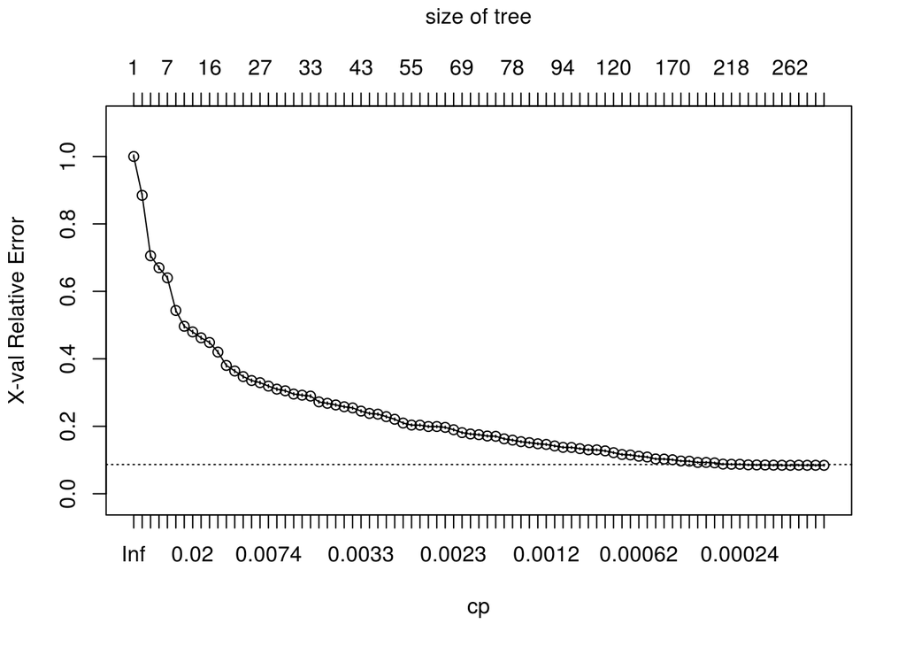

Let’s zoom in to the interesting area:

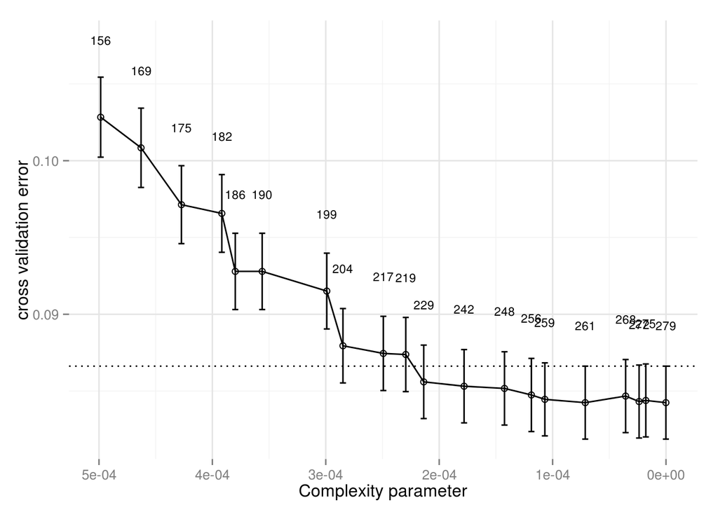

### Pruning

The tree was pruned in order to achieve a minimum cross validation error rate. Therefore, the first CP value with lowest cross validation error was used to prune the tree. An alternative would have been to use the first CP value whose cross validation error is in the range of the lowest cross validation error +- the standard error but too much accuracy was lost using this CP.

## Cross validation and out-of-sample error

### Confusion matrix and resubstitution error

```
##
##        A    B    C    D    E
##   A 5478   54   23   14   11
##   B   63 3608   75   32   19
##   C   18   48 3306   43    7
##   D   19   27   35 3107   28
##   E    5   65   20   45 3472
```

### Out-of-sample error

For a better prediction of accuracy, it is robust to use the error rate computed using a 10-fold cross validation (directly done in rpart) :

```
##           CP       nsplit    rel error       xerror         xstd
## 7.121493e-05 2.610000e+02 4.636092e-02 8.424726e-02 2.374436e-03
```

Here is the estimate of the out-of-sample error (with the chosen CP):

```r
Out_of_sample_error<-0.08424726*0.71563*100
Out_of_sample_error
```

```
## [1] 6.028987
```

The estimated out-of-sample accuracy is therefore: 93.97%